# Analysis of a Bike Sharing Service

Mesum Isfahany

2022-03-16

## Problem Statement

In this project, we will be looking the R programming language to look at Cyclistic, a bike sharing company in Chicago. The main question we wish to answer is how to convert casual riders to annual members because they generate the most profit for the company. In order to develop an effective marketing plan, we need to first differentiate the casual riders from Annual Members.

## Loading the Libraries

For the purpose of this analysis we will be using the following libraries to clean, organize, calculate summary statistics and visualize the data

```r
library(dplyr)
library(tidyverse)
library(ggplot2)
library(lubridate)
```

## Loading the data from as a CSV into R

```r
df <- read_csv('202004-divvy-tripdata.csv')
```

## Understanding the Data

Before we begin analyzing the data, we need to first get a general understanding of the data and what it contains in order to proceed with our analysis in a more informed fashion.

```r
head(df)
```

```
## # A tibble: 6 x 13
##   ride_id rideable_type started_at          ended_at            start_station_n~
##   <chr>   <chr>         <dttm>              <dttm>              <chr>
## 1 A847FA~ docked_bike   2020-04-26 17:45:14 2020-04-26 18:12:03 Eckhart Park
## 2 5405B8~ docked_bike   2020-04-17 17:08:54 2020-04-17 17:17:03 Drake Ave & Ful~
## 3 5DD24A~ docked_bike   2020-04-01 17:54:13 2020-04-01 18:08:36 McClurg Ct & Er~
## 4 2A59BB~ docked_bike   2020-04-07 12:50:19 2020-04-07 13:02:31 California Ave ~
## 5 27AD30~ docked_bike   2020-04-18 10:22:59 2020-04-18 11:15:54 Rush St & Hubba~
## 6 356216~ docked_bike   2020-04-30 17:55:47 2020-04-30 18:01:11 Mies van der Ro~
## # ... with 8 more variables: start_station_id <dbl>, end_station_name <chr>,
## #   end_station_id <dbl>, start_lat <dbl>, start_lng <dbl>, end_lat <dbl>,
## #   end_lng <dbl>, member_casual <chr>
```

```r
str(df)
```

```
## spec_tbl_df [84,776 x 13] (S3: spec_tbl_df/tbl_df/tbl/data.frame)
##  $ ride_id           : chr [1:84776] "A847FADBBC638E45" "5405B80E996FF60D" "5DD24A79A4E006F4" "2A59BBDF5CDBA725" ...
##  $ rideable_type     : chr [1:84776] "docked_bike" "docked_bike" "docked_bike" "docked_bike" ...
##  $ started_at        : POSIXct[1:84776], format: "2020-04-26 17:45:14" "2020-04-17 17:08:54" ...
##  $ ended_at          : POSIXct[1:84776], format: "2020-04-26 18:12:03" "2020-04-17 17:17:03" ...
##  $ start_station_name: chr [1:84776] "Eckhart Park" "Drake Ave & Fullerton Ave" "McClurg Ct & Erie St" "California Ave & Division St" ...
##  $ start_station_id  : num [1:84776] 86 503 142 216 125 173 35 434 627 377 ...
##  $ end_station_name  : chr [1:84776] "Lincoln Ave & Diversey Pkwy" "Kosciuszko Park" "Indiana Ave & Roosevelt Rd" "Wood St & Augusta Blvd" ...
##  $ end_station_id    : num [1:84776] 152 499 255 657 323 35 635 382 359 508 ...
##  $ start_lat         : num [1:84776] 41.9 41.9 41.9 41.9 41.9 ...
##  $ start_lng         : num [1:84776] -87.7 -87.7 -87.6 -87.7 -87.6 ...
##  $ end_lat           : num [1:84776] 41.9 41.9 41.9 41.9 42 ...
##  $ end_lng           : num [1:84776] -87.7 -87.7 -87.6 -87.7 -87.7 ...
##  $ member_casual     : chr [1:84776] "member" "member" "member" "member" ...
##  - attr(*, "spec")=
##   .. cols(
##   ..   ride_id = col_character(),
##   ..   rideable_type = col_character(),
##   ..   started_at = col_datetime(format = ""),
##   ..   ended_at = col_datetime(format = ""),
##   ..   start_station_name = col_character(),
##   ..   start_station_id = col_double(),
##   ..   end_station_name = col_character(),
##   ..   end_station_id = col_double(),
##   ..   start_lat = col_double(),
##   ..   start_lng = col_double(),
##   ..   end_lat = col_double(),
##   ..   end_lng = col_double(),
##   ..   member_casual = col_character()
##   .. )
##  - attr(*, "problems")=<externalptr>
```

## Checking and Cleaning the Data

Now we will clean the data, to make sure there are no missing values, outliers or duplicates. The standard stuff!.

```r
is.null(df)
```

```
## [1] FALSE
```

```r
mean(duplicated(df))
```

```
## [1] 0
```

**duplicted** would have returned a true or false, if there were any duplicated values and displayed them all. We use the mean function to calculate the average number of duplicated values. An answer of 0 meant that there were none because FALSE is a boolean data type with the integer value of 0.

## Renaming the columns

Before before beginning the preliminary analysis, i would like to rename the **member_casual** column to **member_type** to make it more descriptive.

```r
df <- rename(df, member_type = member_casual)
```

## The differences between the two member types

Now we will be look at the differences between casual riders and annual members. We will start by looking at the frequency of member tyoe

```r
df %>%
  group_by(member_type) %>%
  count()
```

```
## # A tibble: 2 x 2
## # Groups:   member_type [2]
##   member_type     n
##   <chr>       <int>
## 1 casual      23628
## 2 member      61148
```

# The fundemental differences

To do so we will be looking at two main things based on the information available to us. The trip duration and which days each member type is more likely to use the service. So we wil be deriving the following columns: - + Ride Length + Day of the week

## Adding a ‘ride_length’ column

We include a ride length or ride duration column by subtracting the end time and start time of every trip in order to help determine whether ride duration plays any part in differeniating between casual riders and annual members

```r
df['ride_length'] = df['ended_at'] - df['started_at']
```

## Calculating the Average Trip Duration

```r
avg_trip <- df %>%
  group_by(member_type) %>%
  summarize(mean(ride_length))

avg_trip
```

```
## # A tibble: 2 x 2
##   member_type `mean(ride_length)`
##   <chr>       <drtn>
## 1 casual      4384.271 secs
## 2 member      1288.050 secs
```

We calculate the aveage trip duration for each member type and store it in a variable **avg_trip** to visualize the data.

## Visualising Ride length and membership status

Before visualizing the Average trip length, we will convert it into a data frame to make it easier to work with

```r
avg_trip <- data.frame(avg_trip)
colnames(avg_trip) <- c("member_type", "avg_ride_length")
```

Now we will visualize the data using a column chart

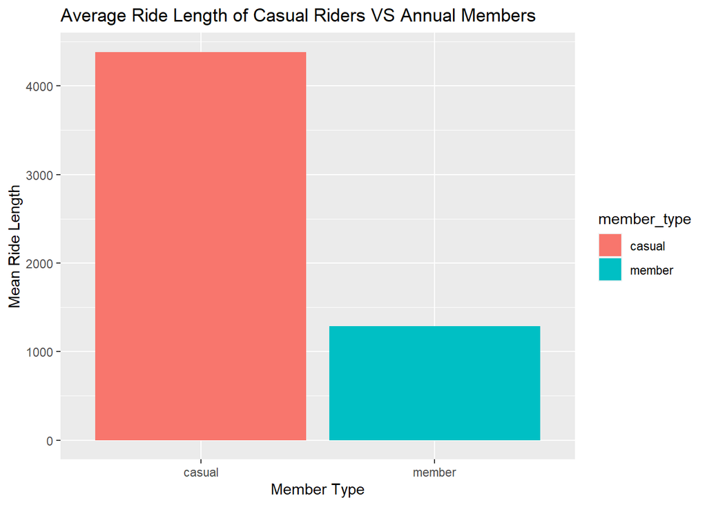

```r
ggplot(data=avg_trip) +
  geom_col(mapping = aes(x=member_type, y=avg_ride_length, fill=member_type)) +
  labs(title="Average Ride Length of Casual Riders VS Annual Members") + xlab("Member Type") + ylab("Mean Ride Length")
```

# Adding a Day of the Week column

We calculate the day of the week in this dataset to get aninsight into whether it plays an impact on membership status

```r
df['day_of_week'] = weekdays(as.Date(df$started_at))
```

## Comparing Days of the week with membership status

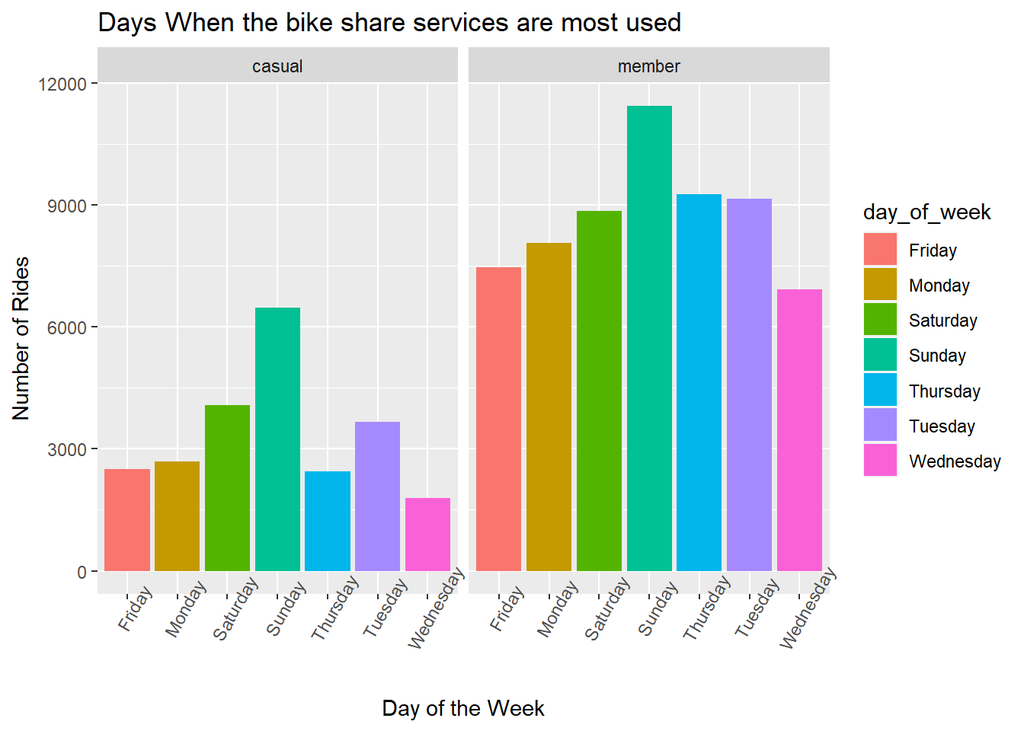

```r
ggplot(data=df) +
  geom_bar(mapping = aes(x=day_of_week, fill=day_of_week)) +
  facet_wrap(~member_type) +
  theme(axis.text.x = element_text(angle = 60)) +
  labs(title="Days When the bike share services are most used") +
  xlab("Day of the Week") +
  ylab("Number of Rides")
```

Keeping the frequency of usage aside, w can see that annual members tend to have a more consistent usage of services, with a peak on sundays whereas casual members display an irregular pattern of usage which may be more obvious if the data was more comprehensive.

## Continuing our analysis

The data does not provide information such as user ID, which we could have used to determine the riding pattern of each member, an whether they have a routine which they follow which could in term play a role in them subscribing to the annual membership program.

```r
df['start_time'] <- round_date(df$started_at, "hours")
df['start_time'] <- format(df$start_time, format = '%H:%M:%S')
sorted_df <- df[c('member_type', 'start_time', 'day_of_week')]
#sorted_df <- sorted_df[order(start_time),]
write.csv(sorted_df,"Sorted_data.csv", row.names= TRUE)
```

## The Dashboard

Using Power BI, we build this interactive [dashboard](https://github.com/mesumisfahany/bike-share-analysis-using-r/blob/main/Bike%20Share%20Visual.pdf) to make it easier to visualise what time of the day, casual riders and annual members were most likely to use a service on a given weekday, sorting the data by **start_time**

We notice that there is a lot of similarity between casual riders and annual members in their riding patterns however, members tend to go on a lot of early morning rides (between 7 to 9am) on weekdays which could be to go to work or just a healthy habit. And casual riders go on evening rides more frequently.

From a business perspective there could be two reason for this difference. * Casual Riders find the annual membership too expensive for their daily use, which explains why there is a similar pattern but lower frequency * Annual members are people who generally have more healthy habits

## Reccomendations

The Marketing team at Cyclistic should focus on an ad campaign which promotes cyclying as a healthy lifestyle, focusing on the benefits of daily early morning cyclying rides. When casual members adopt this daily habit, they will be more likely to purchase an annual membership which in turn would lead to greater profits for the company